# Interpreting price × attribute interaction coefficients in a discrete choice experiment

A methodological note on price × attribute interaction specification

Published

March 30, 2026

**Note**

This report was generated using AI under human direction. The contents have been comprehensively reviewed and validated by Nick Christie

# Overview

This note explores whether the marginal disutility of price varies across attribute levels — a reasonable and substantively interesting concern. Interacting the price coefficient with each attribute level is a natural way to approach this question, and the resulting coefficient grid is produced here.

In practice, however, this approach is difficult to implement cleanly within a utility-based discrete choice framework. The mixed logit model imposes a structure that limits what alternative specifications can deliver: interaction terms modify the effective price sensitivity in the model but do not straightforwardly translate into comparable monetary values, and the non-linear utility scale makes cross-attribute comparisons inherently ambiguous. These are not flaws in the question — they are constraints imposed by the framework itself. This note works through each challenge in turn and concludes that the MWTP estimates from the baseline model (Tables 3–4 of the paper) remain the most appropriate summary of how respondents value each attribute, with the interaction coefficient grid serving as potential supplementary evidence on the direction of price sensitivity across levels.

# Model specification

The paper uses a mixed logit (MXL) model with correlated random parameters. The baseline utility function for respondent $i$ choosing alternative $j$ in choice occasion $t$ is:

$$U_{ijt} = \sum_{a} \beta_{ia} \cdot x_{ajt} + \beta_p \cdot \text{price}_{jt} + \varepsilon_{ijt}$$

where $x_{ajt}$ are dummy-coded attribute levels, $\text{price}_{jt}$ is the price variable, and $\beta_{ia}$ are individual-level random coefficients drawn from a multivariate normal distribution.

The **price × attribute interaction model** adds fixed interaction terms:

$$U_{ijt} = \sum_{a} \beta_{ia} \cdot x_{ajt} + \beta_p \cdot \text{price}_{jt} + \sum_{a} \beta_{pa} \cdot (\text{price}_{jt} \times x_{ajt}) + \varepsilon_{ijt}$$

The additional term $\beta_{pa}$ estimates whether the marginal disutility of price changes when a particular attribute level is present. If $\beta_{pa} > 0$, price is *less* disutilising when that attribute level is in the scenario.

# Attribute coding and reference levels

All attributes are **dummy-coded**: for each attribute with $k$ levels, $k - 1$ binary (0/1) indicator variables are created, with one level designated as the reference.

| Attribute | Reference level (coded 0) | Non-reference levels (coded 1) |
| --- | --- | --- |
| Distance to green space | 15 km | 5 km; 500 m |
| Distance to shops | 15 km | 5 km; 500 m |
| Distance to public transit | 900 m | 600 m; 300 m |
| Parking | None | Reserved space; Reserved garage |
| Housing cost | 0% change (current cost) | −20%; +20% |

Each coefficient therefore represents the **utility change relative to the reference level**, not an absolute effect. A coefficient of 2.0 on `green5km` means “an option with green space 5 km away is preferred by 2.0 utility units over an otherwise identical option with green space 15 km away.”

# The non-symmetrical interval problem

This is perhaps the most fundamental challenge in comparing coefficients across levels and attributes.

## Unequal physical intervals within an attribute

Each dummy variable is binary (0 or 1), so on the *variable scale* all dummies look equally sized. But the physical changes they represent are not equal:

| Attribute | Dummy | From (reference) | To | Physical change |
| --- | --- | --- | --- | --- |
| Green space | green5km | 15 km | 5 km | −10 km |
|  | green500m | 15 km | 500 m | −14.5 km |
| Shops | shops5km | 15 km | 5 km | −10 km |
|  | shops500m | 15 km | 500 m | −14.5 km |
| Transit | trans600 | 900 m | 600 m | −300 m |
|  | trans300 | 900 m | 300 m | −600 m |
| Parking | park_space | None | Reserved space | qualitative |
|  | park_garage | None | Reserved garage | qualitative |

The ratio $\beta_{\text{green500m}} / \beta_{\text{green5km}}$ is **not** the marginal utility per kilometre of green-space proximity. It is simply the contrast between two different reference-to-level gaps — one of 14.5 km and one of 10 km. Since the DCE did not include intermediate levels, we cannot interpolate between them.

## Incommensurable units across attributes

Beyond the within-attribute problem, coefficients across attributes represent physically incomparable interventions:

- $\beta_{\text{green5km}}$: utility of reducing green-space distance by 10 km
- $\beta_{\text{trans600}}$: utility of reducing transit distance by 300 m
- $\beta_{\text{park\_garage}}$: utility of gaining access to a reserved garage (qualitative)

All three values appear on the same utility scale, but the underlying quantities they describe — kilometres, metres, parking quality — share no common metric. Ranking attributes by coefficient magnitude does not rank them by “importance”, because each coefficient reflects a physically different-sized change.

**ImportantConsequence for the coefficient grid**

The price × attribute interaction grid shows $\beta_{pa}$ for each attribute level. These coefficients are subject to both layers of non-comparability: (1) unequal physical intervals within attributes, and (2) incommensurable units across attributes. A larger $\beta_{p, \text{green5km}}$ relative to $\beta_{p, \text{trans600}}$ does not mean that price sensitivity is more strongly tied to green space than to transit — it partly reflects the different physical magnitudes of the two level differences.

# Price coding

## How price is measured

The price variable in the DCE represents a percentage change from each respondent’s planned monthly housing cost. In the model:

$$\texttt{price\_num} = \frac{\texttt{raw\_price}}{100}, \quad \texttt{raw\_price} \in \{-20,\ 0,\ +20\}$$

So `price_num` ∈ {−0.2, 0, 0.2}: it is a **fraction of planned monthly cost**, not an absolute SEK amount.

## Implications for coefficient interpretation

A “one-unit change” in `price_num` would represent a 100% cost increase — an interval that does not appear in the data. The entire observed range is 0.4 units. The price coefficient $\beta_p \approx -6$ means:

> “A 0.1-unit increase in `price_num` (i.e. a 10% increase in planned cost) reduces utility by approximately 0.6 units.”

This is only interpretable once anchored to a specific planned cost level.

## Individual heterogeneity in the price anchor

Because planned costs vary across respondents, the price coefficient absorbs a *distribution* of individual monetary references, not a fixed SEK unit.

| Own | N | Median (SEK) | Mean (SEK) | SD (SEK) | 10% of median (scaler) |
| --- | --- | --- | --- | --- | --- |
| Owner | 790 | 10,000 | 10,446 | 4,064 | 1,000 |
| Renter | 167 | 9,000 | 10,480 | 5,568 | 900 |

The MWTP scaler (`0.10 × median planned cost`) anchors this to a 10% change at the group median — a convention that makes MWTP values concrete, but it means owner and renter MWTPs are on slightly different absolute scales.

# The price × attribute interaction coefficients

## What they test

Each interaction term takes the form:

$$\texttt{p\_green5km} = \texttt{price\_num} \times \mathbb{1}[\text{green space} = 5\text{km}]$$

This variable equals `price_num` when the scenario has 5 km green space, and 0 otherwise. Its coefficient $\beta_{p,\text{green5km}}$ captures: **does the marginal disutility of price change when green space is at 5 km?**

## The coefficient grid

| Attribute | Owners Owner | Renters Renter |
| --- | --- | --- |
| Price | -5.05*** (1.23) | -19.98*** (4.64) |
| Green space: 5 km (vs 15 km) | 0.39** (0.14) | 1.22** (0.45) |
| Green space: 500 m (vs 15 km) | 1.61*** (0.16) | 4.15*** (0.63) |
| Shops: 5 km (vs 15 km) | 0.88*** (0.14) | 2.43*** (0.50) |
| Shops: 500 m (vs 15 km) | 3.01*** (0.17) | 5.16*** (0.62) |
| Transit stop: 600 m (vs 900 m) | 0.47*** (0.13) | 1.60*** (0.41) |
| Transit stop: 300 m (vs 900 m) | 1.27*** (0.15) | 2.15*** (0.46) |
| Parking: reserved garage (vs none) | 3.11*** (0.27) | 3.07*** (0.42) |
| Parking: reserved space (vs none) | 2.45*** (0.16) | 3.08*** (0.46) |
| Price × Green space: 5 km (vs 15 km) | -0.54 (0.97) | 3.82 (3.26) |
| Price × Green space: 500 m (vs 15 km) | -0.01 (1.02) | 6.69* (3.35) |
| Price × Shops: 5 km (vs 15 km) | 0.72 (0.71) | 1.63 (1.99) |
| Price × Shops: 500 m (vs 15 km) | 0.01 (0.83) | 2.22 (2.26) |
| Price × Transit stop: 600 m (vs 900 m) | -2.48* (1.19) | 6.37* (3.16) |
| Price × Transit stop: 300 m (vs 900 m) | 1.42 (1.04) | 10.09*** (3.01) |
| Price × Parking: reserved garage (vs none) | 0.60 (0.63) | -0.82 (1.88) |
| Price × Parking: reserved space (vs none) | 0.93 (0.80) | 0.95 (2.51) |

Standard errors in parentheses. * p<0.05 ** p<0.01 *** p<0.001. Grey: price coefficient. Light grey: attribute main effects (relative to reference level). Blue: price × attribute interaction terms.

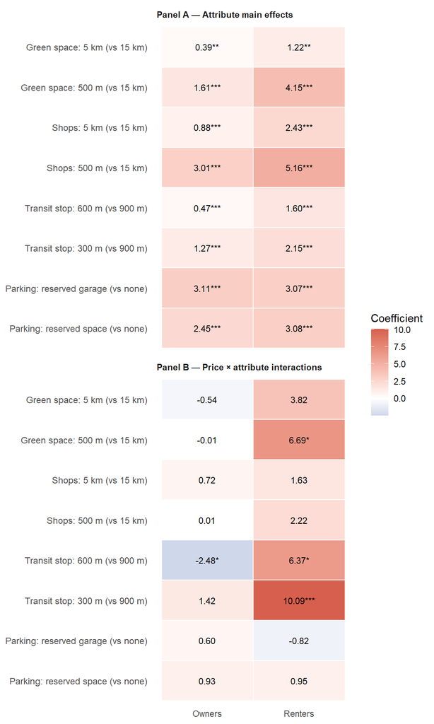

Coefficient heatmap: attribute main effects (Panel A) and price × attribute interactions (Panel B). Blue = negative coefficient; red = positive. Significance stars: * p<0.05 ** p<0.01 *** p<0.001.

**WarningWhy the colours cannot be directly compared**

1. **Different physical magnitudes per tile:** Each row represents a different-sized real-world change. A deep red for `green5km` (a 10 km improvement in green-space proximity) and a deep red for `trans300` (a 600 m improvement in transit distance) look identical on the heatmap but represent interventions that differ by a factor of ~17 in physical distance — and are in different units entirely.
2. **Qualitative vs quantitative levels:** The parking rows represent a qualitative step (none → reserved space → reserved garage) with no natural metric. Colour intensity there carries no physical interpretation.
3. **Price not on an absolute scale:** The price coefficient — and therefore the Panel B interaction coefficients — is anchored to individual planned costs, not a fixed SEK amount. Comparing the magnitude of `p_green5km` to `p_trans600` on the colour scale is similarly uninformative.
4. **What the heatmap IS useful for:** The sign within a single cell tells you the direction of the effect. The most valid cross-cell comparison is within the same row across tenure groups (Owners vs Renters): same physical change, different respondent groups.

## What can and cannot be read from this grid

**Sign (directional interpretation — valid):** A positive $\beta_{pa}$ means respondents are *more* price-tolerant when that attribute level is present. A negative value means they are *more* price-sensitive in the presence of that level.

**Magnitude (cross-attribute comparisons — not valid):** As discussed in Sections 3 and 4, the magnitudes are not directly comparable across attribute levels. A large $|\beta_{pa}|$ for one attribute does not mean price sensitivity is more strongly tied to that attribute than to another with a smaller coefficient — the physical sizes of the level changes differ.

# Why the interaction model does not yield MWTP in SEK

In the baseline model, MWTP is well-defined because the utility function is **linear in both the attribute and the price**:

$$\text{MWTP}_a = -\frac{\beta_a}{\beta_p} \times \text{scaler}$$

The ratio $-\beta_a / \beta_p$ is a constant — it does not depend on the values of other variables in the choice scenario.

In the price × attribute interaction model, however, the picture changes. The partial derivative of utility with respect to the attribute is:

$$\frac{\partial U}{\partial x_a} = \beta_a + \beta_{pa} \cdot \text{price\_num}$$

The marginal utility of the attribute now **depends on the price level in the scenario**. Similarly, the effective price coefficient when attribute $a$ is present is $\beta_p + \beta_{pa}$. The MWTP therefore varies depending on which price scenario ($-0.2$, $0$, or $+0.2$) accompanies the attribute level — it is no longer a single number.

**WarningMWTP cannot be read from the interaction model**

Any attempt to compute a single MWTP from the price × attribute model requires choosing a specific price level at which to evaluate the derivative — an arbitrary decision that would drive the result. The values are not interpretable in SEK without this assumption.

This is a further reason why the baseline model (which produces clean, scenario-independent MWTP estimates) is the preferred specification for the paper’s main results.

# MWTP from the baseline model

Since the interaction model does not produce clean MWTP values, the table below shows the baseline MWTP (from Table 4 of the paper) — the recommended summary of attribute valuation.

| Attribute | Baseline model (SEK/month) Owner MWTP | Baseline model (SEK/month) Renter MWTP |
| --- | --- | --- |
| Green space: 5 km (vs 15 km) | 200 | 214 |
| Green space: 500 m (vs 15 km) | 397 | 346 |
| Shops: 5 km (vs 15 km) | 184 | 171 |
| Shops: 500 m (vs 15 km) | 598 | 408 |
| Transit stop: 600 m (vs 900 m) | 74 | 46 |
| Transit stop: 300 m (vs 900 m) | 227 | 134 |
| Parking: reserved garage (vs none) | 587 | 254 |
| Parking: reserved space (vs none) | 478 | 249 |

MWTP = −(β_attribute / β_price) × scaler. Scaler: 10% of median monthly planned housing cost (owners: 10,000 SEK; renters: 9,000 SEK). Interpretation: estimated SEK/month a respondent would accept as a cost increase in exchange for the stated improvement in each attribute, relative to its reference level.

These values address the underlying question — “how much do respondents value each attribute?” — in a monetarily interpretable way. The price × attribute coefficient grid (Section 5) provides additional information about whether price sensitivity varies with attribute levels, but it operates on the utility scale rather than a monetary scale and could be treated as supplementary.

# Summary and recommendation

The price × attribute coefficient grid is produced as requested. The key interpretive points are:

1. **Reference-level dependence:** All coefficients are contrasts vs the reference level. Changing the reference level changes all coefficients.
2. **Non-symmetrical intervals:** Each dummy represents a different-sized physical change. Coefficient magnitudes are not directly comparable across levels or attributes.
3. **Price scale:** `price_num` is a fraction of individual planned costs, not a fixed monetary unit. Raw price coefficients are only interpretable after applying a scaler.
4. **No clean MWTP from the interaction model:** Because the marginal utility of an attribute depends on the price level in the interaction model ($\partial U / \partial x_a = \beta_a + \beta_{pa} \cdot \text{price}$), MWTP is not a scenario-independent quantity. The formula $-\beta_a / \beta_p$ does not apply.

**Recommendation:** The MWTP table from the baseline model (reproduced in Section 7) directly addresses the valuation question and should remain the primary result. The price × attribute coefficient grid can accompany it as a supplementary specification check, with the caveats above noted clearly.